# R Notebook

# Trait Estimates And Community Fitted Values

This script includes all the models of trait estimates, the fitted mean values for each species, and the estimates of the variances for each community.

There are some really big multivariate models and big functions here. The Notebook becomes really long because of this, but I thought it would be easier to look in one place for all of these functions rather than across a different script for each trait.

I will split them up into sections be headers, and explain as much about what I am doing in them as I can.

All of these scripts rely heavily on the **tidyverse**, **tidybayes**, and the Bayesian multilevel modeling package **brms**.

Load some general packages and write some common functions

```r
pacman::p_load(here, tidyverse, brms, tidybayes, patchwork, modelr, cmdstanr, paletteer)

here::i_am('Code/Models_Fitted_Variance.Rmd')
```

```
## here() starts at /Users/Dicrostonyx/Library/Mobile Documents/com~apple~CloudDocs/Documents/Projects/Sulawesi/Manuscript/Submission_2_FunEco/Repo
```

```r
scale2 <- function(x, na.rm = TRUE) (x - mean(x, na.rm = na.rm)) / sd(x, na.rm)
# Species lists of all Sulawesi Species by community. Used to group species by community.
load(here("Species_Data", "Species_Lists.Rdata"))
# order of communities by richness
level_order <-  c( 'Bawakaraeng', 'Buliohuto','Dako', "Katopasa", "Ambang", "Latimojong", "Torompupu", "Nokilalaki", "Gandangdewata")
```

# Cranium

The cumulative variances are stored in a file called `Cranial_PCA_Eigen_Variance.csv` in the `~/Cranial_Data/landmarks` directory. Same for Dentary Data (in Dentary directory).

## Cranial Model

Data *DO NOT SCALE PCA DATA*

```r
pdat <- read_csv(here("Cranial_Data", "Cranial_PCA_Data_36axes.csv")) %>%
  mutate(Csize = scale2(Csize))
```

```
## ──────────────────────────────────────────────────────────── Delimiter: "," chr
## (6): ...1, Genus, Species, Clade, SubClade, SubClade_Frat dbl (37): PC1, PC2, PC3,
## PC4, PC5, PC6, PC7, PC8, PC9, PC10, PC11, PC12, PC13, P...
## the column types or set `show_col_types = FALSE` to quiet this message.
```

This is a multivariate model. Basically it is 36 models - one for each of the 36 cranial PCs - run at once, for ease. This uses partial pooling to estimate a distribution of predicted values for each species. See text for more info.

```r
mvcmod <- bf(PC1 ~ 0 + (1|Species)) +
          bf(PC2 ~ 0 + (1|Species)) +
          bf(PC3 ~ 0 + (1|Species)) +
          bf(PC4 ~ 0 + (1|Species)) +
          bf(PC5 ~ 0 + (1|Species)) +
          bf(PC6 ~ 0 + (1|Species)) +
          bf(PC7 ~ 0 + (1|Species)) +
          bf(PC8 ~ 0 + (1|Species)) +
          bf(PC9 ~ 0 + (1|Species)) +
          bf(PC10 ~ 0 + (1|Species)) +
          bf(PC11 ~ 0 + (1|Species)) +
          bf(PC12 ~ 0 + (1|Species)) +
          bf(PC13 ~ 0 + (1|Species)) +
          bf(PC14 ~ 0 + (1|Species)) +
          bf(PC15 ~ 0 + (1|Species)) +
          bf(PC16 ~ 0 + (1|Species)) +
          bf(PC17 ~ 0 + (1|Species)) +
          bf(PC18 ~ 0 + (1|Species)) +
          bf(PC19 ~ 0 + (1|Species)) +
          bf(PC20 ~ 0 + (1|Species)) +
          bf(PC21 ~ 0 + (1|Species)) +
          bf(PC22 ~ 0 + (1|Species)) +
          bf(PC23 ~ 0 + (1|Species)) +
          bf(PC24 ~ 0 + (1|Species)) +
          bf(PC25 ~ 0 + (1|Species)) +
          bf(PC26 ~ 0 + (1|Species)) +
          bf(PC27 ~ 0 + (1|Species)) +
          bf(PC28 ~ 0 + (1|Species)) +
          bf(PC29 ~ 0 + (1|Species)) +
          bf(PC30 ~ 0 + (1|Species)) +
          bf(PC31 ~ 0 + (1|Species)) +
          bf(PC32 ~ 0 + (1|Species)) +
          bf(PC33 ~ 0 + (1|Species)) +
          bf(PC34 ~ 0 + (1|Species)) +
          bf(PC35 ~ 0 + (1|Species)) +
          bf(PC36 ~ 0 + (1|Species)) +
          bf(Csize ~ 0 + (1|Species)) +
               set_rescor(FALSE)

mvcPC2<- brm(mvcmod,
          data = pdat,
          family = gaussian(),
          iter = 5000,
          warmup = 4000,
          refresh = 0,
          cores = 4,
          #DEFAULT PRIORS ARE GOOD HERE! Student-t distribution.
          file = here("Models","Cranium_36_PC_fitted"),
          backend = 'cmdstanr')
```

## Cranial Predicted Values

Fitted values for PC1-36 and centroid size for each species. In short this means re running the original data through the model output to get the “fitted” values. So using the data as both a training and testing set.

```r
pre.cranium_t <- pdat %>%
  data_grid(Species) %>%
  add_fitted_draws(mvcPC2) %>%
  spread(.category, .value) %>%
  rename_with(~ gsub("PC", "cPC", .x)) %>%
  rename(cCsize = Csize) %>%
  select(!c(.chain, .iteration))
write_csv(pre.cranium_t, here("Cranial_Data","Cranial_36axes_Fitted.csv"))
```

## Cranium Variace and Volumes By Community

```r
get_cran <- function(sp, data, mountain) {
  data %>%
    filter(Species %in% {{sp}}) %>%
    select(!Species) %>%
    select(!.row) %>%
    group_by(.draw) %>%
    summarise_at(vars(cPC1:cCsize), var) %>%
    mutate(cv_wei = select(., cPC1:cPC36) %>% rowSums(na.rm = TRUE),
           vcCsize = cCsize) %>%
    select(.draw, vcCsize, cv_wei) %>%
    add_column(com = {{mountain}})
}


cambt <- get_cran(spamb, pre.cranium_t, "Ambang")
cbawt <- get_cran(spbaw, pre.cranium_t, "Bawakaraeng")
cbult <- get_cran(spbul, pre.cranium_t, "Buliohuto")
cdakt <- get_cran(spdak, pre.cranium_t, "Dako")
cgant <- get_cran(spgan, pre.cranium_t, "Gandangdewata")
ckatt <- get_cran(spkat, pre.cranium_t, "Katopasa")
clatt <- get_cran(splat, pre.cranium_t, "Latimojong")
cnokt <- get_cran(spnok, pre.cranium_t, "Nokilalaki")
ctort <- get_cran(sptor, pre.cranium_t, "Torompupu")
cct <- bind_rows(cambt, cbawt, cbult, cdakt, cgant, ckatt, clatt, cnokt, ctort)
rm(cambt, cbawt, cbult, cdakt, cgant, ckatt, clatt, cnokt, ctort)
write_csv(cct, here("Cranial_Data","Community_Cranial_Variance_Weighted.csv"))
```

#### Quick Plot

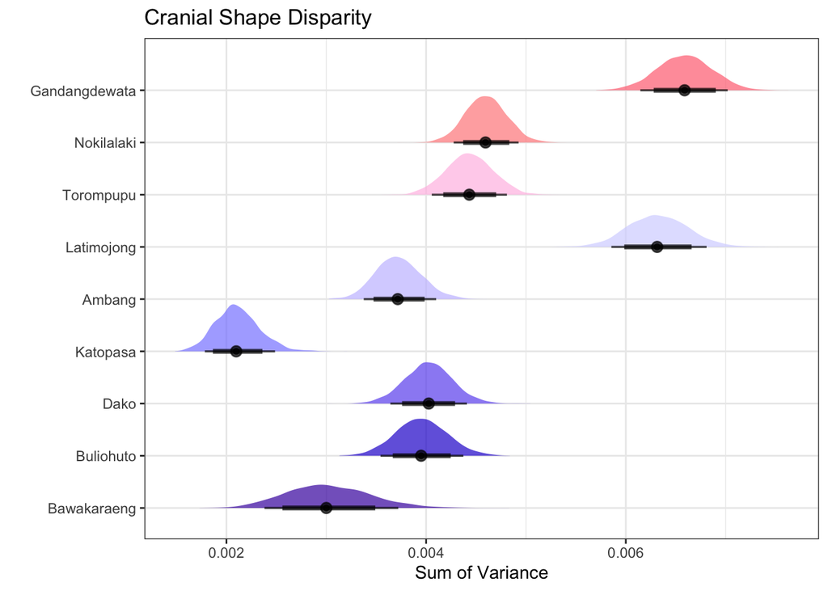

```r
#cct %>% mutate(cv_wei = (cv_wei / 36)) %>%
cct %>% mutate(com = factor(com, level = level_order)) %>%
ggplot(aes(y = com, x = cv_wei, fill = com)) +
  stat_halfeye(.width = c(0.74, 0.89),  alpha = 0.7) +
   labs(title="Cranial Shape Disparity",x="Sum of Variance", y = "", fill = "Mountain") +
  theme_bw() +
  scale_fill_paletteer_d('ggsci::default_gsea', direction = 1) +
  guides(fill = guide_legend(reverse=T)) + theme(legend.position = "none")
```

Looks Good. Move on to Dentary

# Dentary

First load some data and remove the previous data to save RAM

```r
ddat <- read_csv(here("Dentary_Data", "Dentary_PCA_Data_20axes.csv")) %>%
  mutate(Csize = scale2(Csize))
```

```
## ──────────────────────────────────────────────────────────── Delimiter: "," chr
## (6): ...1, Genus, Species, Clade, SubClade, SubClade_Frat dbl (21): PC1, PC2, PC3,
## PC4, PC5, PC6, PC7, PC8, PC9, PC10, PC11, PC12, PC13, P...
## the column types or set `show_col_types = FALSE` to quiet this message.
```

```r
rm(cct, pre.cranium_t, mvcPC2, mvcmod)
```

## Dentary Model

Same thing as the multivariate model for cranium above.

```r
mvdmod <- bf(PC1 ~ 0 + (1|Species)) + bf(PC2 ~ 0 + (1|Species)) + bf(PC3 ~ 0 + (1|Species)) + bf(PC4 ~ 0 + (1|Species)) + bf(PC5 ~ 0 + (1|Species)) + bf(PC6 ~ 0 + (1|Species)) + bf(PC7 ~ 0 + (1|Species)) + bf(PC8 ~ 0 + (1|Species)) + bf(PC9 ~ 0 + (1|Species)) + bf(PC10 ~ 0 + (1|Species)) + bf(PC11 ~ 0 + (1|Species)) + bf(PC12 ~ 0 + (1|Species)) + bf(PC13 ~ 0 + (1|Species)) + bf(PC14 ~ 0 + (1|Species)) + bf(PC15 ~ 0 + (1|Species)) + bf(PC16 ~ 0 + (1|Species)) + bf(PC17 ~ 0 + (1|Species)) + bf(PC18 ~ 0 + (1|Species)) + bf(PC19 ~ 0 + (1|Species)) + bf(PC20 ~ 0 + (1|Species)) + bf(Csize ~ 0 + (1|Species)) + set_rescor(FALSE)

mvdPC2<- brm(mvdmod,
          data = ddat,
          family = gaussian(),
          iter = 5000,
          warmup = 4000,
          refresh = 0,
          cores = 4,
          file = here("Models", "Dentary_20_PC_fitted"),
          backend = "cmdstan")
```

## Dentary Fitted Values

```r
pre.dentary_t <- ddat %>%
  data_grid(Species) %>%
  add_fitted_draws(mvdPC2) %>%
  spread(.category, .value) %>%
  rename_with(~ gsub("PC", "dPC", .x)) %>%
  rename(dCsize = Csize) %>%
  select(!c(.chain, .iteration))
write_csv(pre.dentary_t, here("Dentary_Data", "Dentary_20axes_Fitted.csv"))
```

## Dentary Variace and Volumes By Community

```r
get_dent <- function(sp, data, mountain) {
data %>%
  filter(Species %in% {{sp}}) %>%
  select(!Species) %>%
  select(!.row) %>%
  group_by(.draw) %>%
    summarise_at(vars(dPC1:dCsize), var) %>%
    mutate(dv_wei = select(., dPC1:dPC20) %>% rowSums(na.rm = TRUE),
           vdCsize = dCsize) %>%
    select(.draw, vdCsize, dv_wei) %>%
    add_column(com = {{mountain}})
}
```

```r
dambt <- get_dent(spamb, pre.dentary_t, "Ambang")
dbawt <- get_dent(spbaw, pre.dentary_t, "Bawakaraeng")
dbult <- get_dent(spbul, pre.dentary_t, "Buliohuto")
ddakt <- get_dent(spdak, pre.dentary_t, "Dako")
dgant <- get_dent(spgan, pre.dentary_t, "Gandangdewata")
dkatt <- get_dent(spkat, pre.dentary_t, "Katopasa")
dlatt <- get_dent(splat, pre.dentary_t, "Latimojong")
dnokt <- get_dent(spnok, pre.dentary_t, "Nokilalaki")
dtort <- get_dent(sptor, pre.dentary_t, "Torompupu")
dct <- bind_rows(dambt, dbawt, dbult, ddakt, dgant, dkatt, dlatt, dnokt, dtort)
rm(dambt, dbawt, dbult, ddakt, dgant, dkatt, dlatt, dnokt, dtort)
write_csv(dct, here("Dentary_Data","Community_Dental_Variance_Weighted.csv"))
```

#### Quick Plot

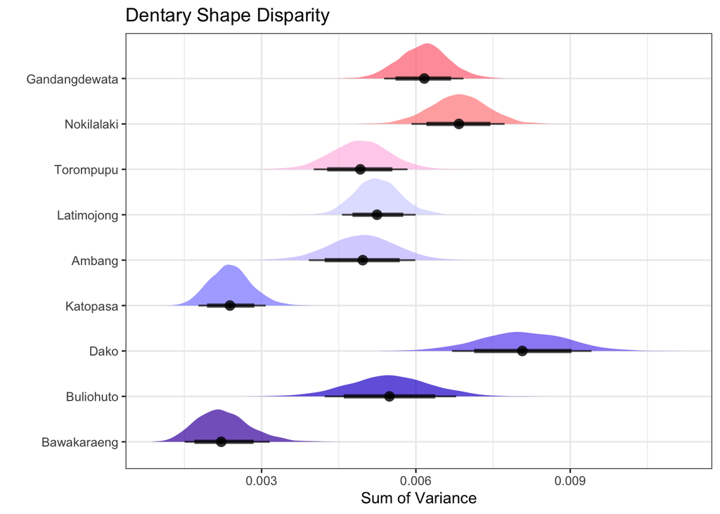

```r
dct %>% mutate(com = factor(com, level = level_order)) %>%
ggplot(aes(y = com, x = dv_wei, fill = com)) +
  stat_halfeye(.width = c(0.74, 0.89),  alpha = 0.7) +
   labs(title="Dentary Shape Disparity",x="Sum of Variance", y = "", fill = "Mountain") +
  theme_bw() +
  scale_fill_paletteer_d('ggsci::default_gsea', direction = 1)  +
  guides(fill = guide_legend(reverse=T)) + theme(legend.position = "none")
```

Looking Good, on to External measurements

#External Measurements

This is the introduction to the external measurment data. These are measurements from over 600 museum specimens. See text for more info. This reads in the data, then generates the size-corrected ratios for each measurement (i.e. relative tail length).

```r
dat <- read_csv(here("External_Measurement_Data", "Measurement_Data_Museum.csv")) %>%
  mutate(loc_state = as_factor(loc_state),
         lMass = log(Mass),
         rHF = HF / HB,
         rEar = Ear / HB,
         rTail = Tail / Total) %>%
  mutate_if(is.numeric, scale2, na.rm = TRUE)
rm(mvdPC2, pre.dentary_t, dct, ddat, mvdmod)
```

## External Measurement Model

Much more simple than the landmark data! Same thing though… one model for each measurement.

```r
exmod <- bf(HB ~ 0 + (1|Species)) +
        bf(rTail ~ 0 + (1|Species)) +
        bf(rHF ~ 0 + (1|Species)) +
        bf(rEar ~ 0 + (1|Species)) +
        bf(lMass ~ 0 + (1|Species)) +
        set_rescor(FALSE)

m.ex1<- brm(exmod,
          data = dat,
          family = gaussian(),
          iter = 5000,
          warmup = 4000,
          refresh = 0,
          cores = 4,
          file = here("Models", "External_Measurement_Fitted"),
          backend = 'cmdstanr')
```

## External Fitted

Fitted values for external measurements for each species

```r
ext_fit <- dat %>%
  data_grid(Species) %>%
  add_fitted_draws(m.ex1) %>%
  spread(.category, .value) %>%
  select(!c(.chain, .iteration))
write_csv(ext_fit , here("External_Measurement_Data", "External_Fitted.csv"))
```

## External Variance

```r
get_ext <- function(sp, data, mountain) {
data %>%
  filter(Species %in% {{sp}}) %>%
  select(!Species) %>%
  select(!.row) %>%
  group_by(.draw) %>%
  summarise(vHB = var(HB),
            vTail = var(rTail),
            vHF = var(rHF),
            vEar = var(rEar),
            vMass = var(lMass),
            #ADDING IN MEAN HERE TO TEST FOR CHANGES IN POSTION
            #NOT SURE IF IT WORKS OR I WANT TO KEEP IT
            mHB_pos = mean(HB),
            mTail_pos = mean(rTail),
            mHF_pos = mean(rHF),
            mEar_pos = mean(rEar),
            mMass_pos = mean(lMass)) %>%
  mutate(ext_sum = vHB + vTail + vHF + vEar) %>%
  mutate(ext_scaled = ext_sum/5) %>%
  add_column(com = {{mountain}})
}
```

```r
dambt <- get_ext(spamb, ext_fit, "Ambang")
dbawt <- get_ext(spbaw, ext_fit, "Bawakaraeng")
dbult <- get_ext(spbul, ext_fit, "Buliohuto")
ddakt <- get_ext(spdak, ext_fit, "Dako")
dgant <- get_ext(spgan, ext_fit, "Gandangdewata")
dkatt <- get_ext(spkat, ext_fit, "Katopasa")
dlatt <- get_ext(splat, ext_fit, "Latimojong")
dnokt <- get_ext(spnok, ext_fit, "Nokilalaki")
dtort <- get_ext(sptor, ext_fit, "Torompupu")
ext <- bind_rows(dambt, dbawt, dbult, ddakt, dgant, dkatt, dlatt, dnokt, dtort)
rm(dambt, dbawt, dbult, ddakt, dgant, dkatt, dlatt, dnokt, dtort)
write_csv(ext, here("External_Measurement_Data", "Community_External_Variance_Fitted.csv"))
```

#### Quick Plot

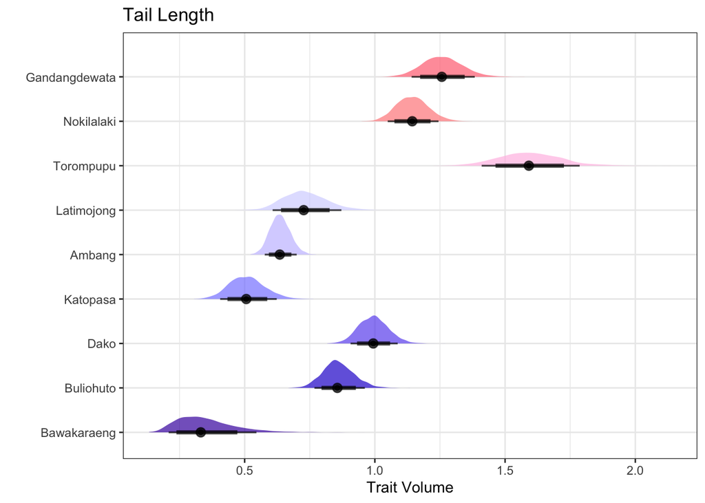

```r
ext %>% mutate(com = factor(com, level = level_order)) %>%
ggplot(aes(y = com, x = vTail, fill = com)) +
  stat_halfeye(.width = c(0.74, 0.89),  alpha = 0.7) +
   labs(title="Tail Length",x="Trait Volume", y = "", fill = "Mountain") +
  theme_bw() +
  scale_fill_paletteer_d('ggsci::default_gsea', direction = 1)  +
  guides(fill = guide_legend(reverse=T)) + theme(legend.position = "none")
```

###########

# Isotopes

This is inherently a bit trickier as each community has it’s own unique isotopic signature. So here I am using a model that includes a second predictor term: The community itself. This generates a isotopic signature for each species, conditioned on the community. So these values work between communities, so we can do randomization (later on).

Data and things

```r
idat <- read_csv(here("Isotope_Data", "Isotope_Data.csv")) %>%
  mutate(sN15 = scale2(Corrected_15N),
         sC13 = scale2(Corrected_13C))
rm(ext, m.ex1, exmod, ext_fit, dat)
```

## Isotope Model

multivariate model, one formula for nitrogen, one for carbon.

```r
imod <- bf(sN15 ~ 0 + (1|Species) + (1|Community)) +
          bf(sC13 ~ 0 + (1|Species) + (1|Community))  +
          set_rescor(FALSE)
options(brms.backend = "cmdstanr")
# Ambang

m.iso <- brm(imod,
          data =  idat,
          family = gaussian(),
          iter = 5000,
          warmup = 4000,
          refresh = 0,
          cores = 4,
          #DEFAULT PRIORS ARE GOOD HERE!
          control = list(adapt_delta = .99,
                         max_treedepth = 12),
          file = here("Models", "iso_fitted_Com_Grouping"))
```

## Isotope fitted

re_formula is clutch here!

```r
iso_fit <- idat %>%
  data_grid(Species) %>%
  add_fitted_draws(m.iso,  re_formula = ~ (1|Species) ) %>%
  spread(.category, .value) %>%
  select(!c(.chain, .iteration))
write_csv(iso_fit , here("Isotope_Data", "Isotope_Group_Level_Fitted.csv"))
```

## Iso Variance

Same thing, the variance for each community for N and C

```r
get_iso <- function(sp, data, mountain) {
data %>%
  filter(Species %in% {{sp}}) %>%
  select(!Species) %>%
  select(!.row) %>%
  group_by(.draw) %>%
  summarise(vN15 = var(sN15),
            vC13 = var(sC13)) %>%
  add_column(com = {{mountain}})
}
```

```r
dambt <- get_iso(spamb, iso_fit, "Ambang")
dbawt <- get_iso(spbaw, iso_fit, "Bawakaraeng")
dbult <- get_iso(spbul, iso_fit, "Buliohuto")
ddakt <- get_iso(spdak, iso_fit, "Dako")
dgant <- get_iso(spgan, iso_fit, "Gandangdewata")
dlatt <- get_iso(splat, iso_fit, "Latimojong")
ivar <- bind_rows(dambt, dbawt, dbult, ddakt, dgant,  dlatt)
rm(dambt, dbawt, dbult, ddakt, dgant, dlatt)
write_csv(ivar, here("Isotope_Data", "Isotope_Group_Level_Variance.csv"))
```

#### Quick Plot

[figure not shown]

```r
ivar %>% mutate(com = factor(com, level = level_order)) %>%
ggplot(aes(y = com, x = vN15, fill = com)) +
  stat_halfeye(.width = c(0.74, 0.89),  alpha = 0.7) +
   labs(title="Tail Length",x="Trait Volume", y = "", fill = "Mountain") +
  theme_bw() +
  scale_fill_paletteer_d('ggsci::default_gsea', direction = 1)  +
  guides(fill = guide_legend(reverse=T)) + theme(legend.position = "none")
```

# Combine Data

Now to finish up I need to combine the sum of variances into one big dataframe. Read in Data

```r
cdat <- read_csv(here("Cranial_Data", "Community_Cranial_Variance_Weighted.csv"))
ddat <- read_csv(here("Dentary_Data", "Community_Dental_Variance_Weighted.csv"))
edat <- read_csv(here("External_Measurement_Data", "Community_External_Variance_Fitted.csv"))
idat <- read_csv(here("Isotope_Data", "Isotope_Group_Level_Variance.csv"))
```

```r
all_var <- cdat %>% right_join(ddat,by = c(".draw", "com")) %>% right_join(edat,by = c(".draw", "com")) %>% full_join(idat,by = c(".draw", "com")) %>%
  mutate(sk_var = (cv_wei + dv_wei) / 2,
         iso_var = (vN15 + vC13) / 2,
         morpho_var = (vMass + vEar + vHF + vTail + vHB + dv_wei + cv_wei) / 7
         )
write_csv(all_var, here("All_Traits.csv"))
```

# Locomotion Variance

This is a little different because there is one categorical (ordinal) value for each species, so there is no model.

```r
locdat <- read_csv(here("Locomotion_Data", "Locomotion_List.csv"))
get_loc <- function(sp, data, mountain) {
data %>%
  filter(Species %in% {{sp}}) %>%
  select(!Species) %>%
  summarise(vloc = var(Loc)) %>%
  add_column(com = {{mountain}})
}
```

```r
locamb <- get_loc(spamb, locdat, "Ambang")
locbaw <- get_loc(spbaw, locdat, "Bawakaraeng")
locbul <- get_loc(spbul, locdat, "Buliohuto")
locdak <- get_loc(spdak, locdat, "Dako")
locgan <- get_loc(spgan, locdat, "Gandangdewata")
lockat <- get_loc(spkat, locdat, "Katopasa")
loclat <- get_loc(splat, locdat, "Latimojong")
locnok <- get_loc(spnok, locdat, "Nokilalaki")
loctor <- get_loc(sptor, locdat, "Torompupu")
vLoc <- bind_rows(locamb, locbaw, locbul, locdak, locgan, lockat, loclat, locnok, loctor) %>%
  mutate(nsp = c(13,7,10,12,23,12,13,17,15)) %>%
write_csv(here("Locomotion_Data", "All_Locomotor_var.csv"))
```